# Prediction Assignment for Practical Machine Learning

ZL

Saturday, March 21, 2015

Background

Using devices such as Jawbone Up, Nike FuelBand, and Fitbit it is now possible to collect a large amount of data about personal activity relatively inexpensively. These type of devices are part of the quantified self movement - a group of enthusiasts who take measurements about themselves regularly to improve their health, to find patterns in their behavior, or because they are tech geeks. One thing that people regularly do is quantify how much of a particular activity they do, but they rarely quantify how well they do it. In this project, our goal is to use data from accelerometers on the belt, forearm, arm, and dumbell of 6 participants to build a statistics model, and use the model to predict the manner in which they did the exercise. More information is available from the website here: http://groupware.les.inf.puc-rio.br/har (see the section on the Weight Lifting Exercise Dataset).

data The training data for this project are available here: https://d396qusza40orc.cloudfront.net/predmachlearn/pml-training.csv The test data are available here: https://d396qusza40orc.cloudfront.net/predmachlearn/pml-testing.csv

data analysis 1. Based on the original paper, the data set consist of 19622 observation of 160 variables, including features on the Euler angles (roll, pitch and yaw), as well as the raw accelerometer, gyroscope and magnetometer readings. For the Euler angles of each of the four sensors, eight features were calculated: mean, variance, standard deviation, max, min, amplitude, kurtosis and skew-ness, generating in total 96 derived feature sets (columns that have data missing). Becasue of limited computation power, I will only use the 60 raw features to build the model, since they capture most of the information.

```r
# ensure the results are repeatable
set.seed(1)

# load the library
library(caret)
# load the data
training<-read.csv("pml-training.csv")
testing<-read.csv("pml-testing.csv")

#remove column with NA
temp<-which(colSums(is.na(training))>1)
subTraining<-training[,-c(temp)]

#remove column with blank
temp<-which(colSums(subTraining == "") != 0)
subTraining<-subTraining[,-c(temp)]
```

2. Some of the attributes in the data set are highly correlated with each other. The findCorrelation function from the Caret R package is used to analyze the correlation matrix of the data attributes, and find attributes that can be removed. After ths step, only 21 features are used to build model.

```r
# calculate correlation matrix
dataOnly<-subTraining[,8:59]
correlationMatrix <- cor(dataOnly)

# summarize the correlation matrix
# print(correlationMatrix)

# find attributes that are highly corrected
highlyCorrelated <- findCorrelation(correlationMatrix, cutoff=0.5)

# print indexes of highly correlated attributes
print(highlyCorrelated)
```

```
##  [1] 10  1  9 22  4  3 36  8  2 11 29 37 35 38 30 47 21 34 39 52 23 25 12
## [24] 48 24 26 19 32 46 45 31
```

```r
reducedDataOnly<-dataOnly[,-highlyCorrelated]
reducedTraining<-reducedDataOnly
reducedTraining$classe<-training$classe
```

3. The importance of features can be estimated from data by building a model. Here, the Learning Vector Quantization (LVQ) model is build. The varImp is then used to estimate the variable importance, which is printed and plotted. It shows that the pitch_forearm, roll_dumbbell, and pitch_dumbbell are the top 3 most important attributes in the dataset.

```r
#rank feature by importance
# ensure results are repeatable
set.seed(1)


# prepare training scheme
control <- trainControl(method="repeatedcv", number=10, repeats=3)
# train the model
model <- train(classe~., data=reducedTraining, method="lvq", preProcess="scale", trControl=control)
# estimate variable importance
importance <- varImp(model, scale=FALSE)
# summarize importance
print(importance)
```

```
## ROC curve variable importance
##
##   variables are sorted by maximum importance across the classes
##   only 20 most important variables shown (out of 21)
##
##                          A      B      C      D      E
## pitch_forearm       0.8043 0.6934 0.7172 0.8043 0.7062
## roll_dumbbell       0.6588 0.6920 0.7561 0.7561 0.6771
## pitch_dumbbell      0.6631 0.7183 0.7183 0.6884 0.6440
## magnet_forearm_x    0.7178 0.6542 0.6212 0.7178 0.6309
## magnet_belt_z       0.6563 0.6526 0.6520 0.6574 0.6574
## pitch_arm           0.6516 0.5849 0.6159 0.6311 0.6516
## magnet_forearm_y    0.6168 0.5782 0.6397 0.6397 0.6097
## total_accel_arm     0.6261 0.5837 0.5966 0.6261 0.6007
## roll_arm            0.6081 0.6081 0.5768 0.5600 0.5572
## roll_forearm        0.6071 0.5758 0.6071 0.5807 0.5508
## total_accel_forearm 0.6004 0.5748 0.5688 0.5856 0.6004
## yaw_forearm         0.5254 0.5715 0.5778 0.5778 0.5756
## gyros_belt_z        0.5598 0.5492 0.5469 0.5598 0.5575
## yaw_arm             0.5532 0.5532 0.5366 0.5405 0.5226
## gyros_forearm_x     0.5146 0.5205 0.5372 0.5372 0.5218
## accel_forearm_z     0.5318 0.5362 0.5362 0.5318 0.5340
## gyros_arm_x         0.5254 0.5226 0.5254 0.5149 0.5215
## gyros_belt_x        0.5233 0.5233 0.5124 0.5063 0.5057
## gyros_dumbbell_z    0.5226 0.5226 0.5110 0.5190 0.5106
## gyros_belt_y        0.5106 0.5097 0.5134 0.5148 0.5148
```

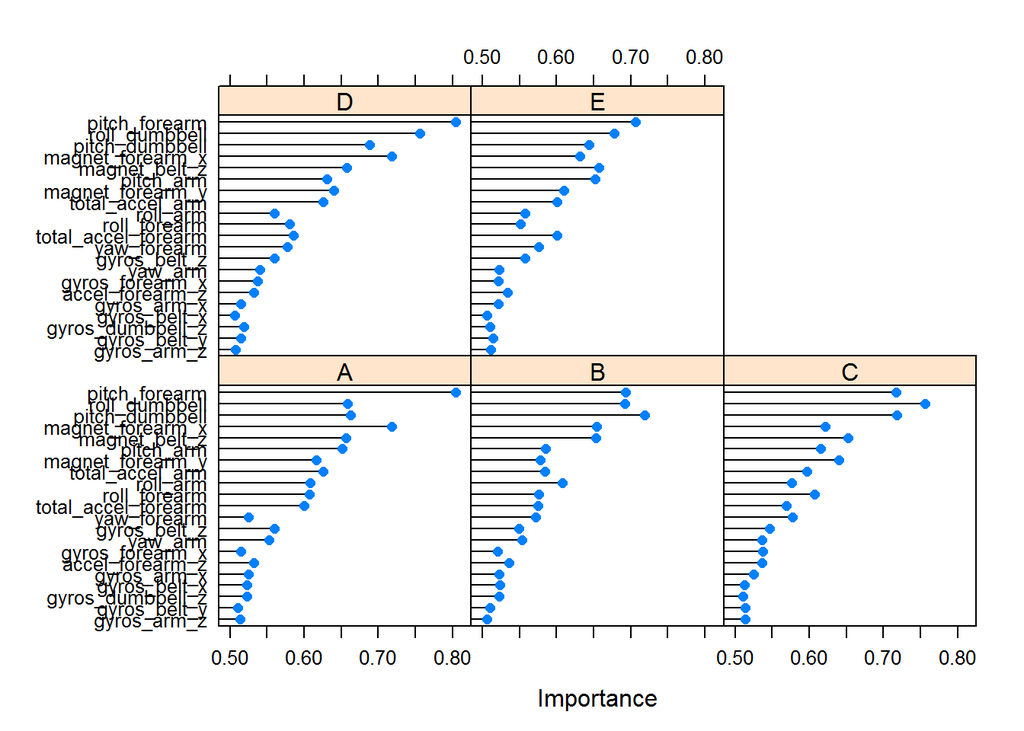

```r
# plot importance
plot(importance)
```

3. Automatic feature selection methods can be used to build many models with different subsets of a dataset and identify those attributes that are and are not required to build an accurate model.

```r
#feature selection

# define the control using a random forest selection function
control <- rfeControl(functions=rfFuncs, method="cv", number=10)
# run the RFE algorithm
results <- rfe(reducedTraining[,1:21], reducedTraining[,22], sizes=c(1:8), rfeControl=control)
# summarize the results
print(results)
```

```
##
## Recursive feature selection
##
## Outer resampling method: Cross-Validated (10 fold)
##
## Resampling performance over subset size:
##
##  Variables Accuracy  Kappa AccuracySD  KappaSD Selected
##          1   0.3365 0.1598   0.010792 0.014190
##          2   0.5524 0.4309   0.015371 0.019597
##          3   0.7375 0.6677   0.024136 0.030251
##          4   0.8487 0.8085   0.014630 0.018285
##          5   0.9040 0.8786   0.008544 0.010824
##          6   0.9381 0.9217   0.005549 0.007010
##          7   0.9491 0.9357   0.005518 0.006981
##          8   0.9594 0.9486   0.004383 0.005539
##         21   0.9871 0.9836   0.001967 0.002488        *
##
## The top 5 variables (out of 21):
##    roll_dumbbell, magnet_belt_z, pitch_forearm, roll_forearm, yaw_arm
```

```r
# list the chosen features
predictors(results)
```

```
##  [1] "roll_dumbbell"       "magnet_belt_z"       "pitch_forearm"
##  [4] "roll_forearm"        "yaw_arm"             "roll_arm"
##  [7] "gyros_belt_z"        "accel_forearm_z"     "magnet_forearm_y"
## [10] "gyros_arm_x"         "total_accel_forearm" "gyros_dumbbell_z"
## [13] "pitch_dumbbell"      "total_accel_arm"     "yaw_forearm"
## [16] "gyros_forearm_x"     "magnet_forearm_x"    "pitch_arm"
## [19] "gyros_belt_x"        "gyros_arm_z"         "gyros_belt_y"
```

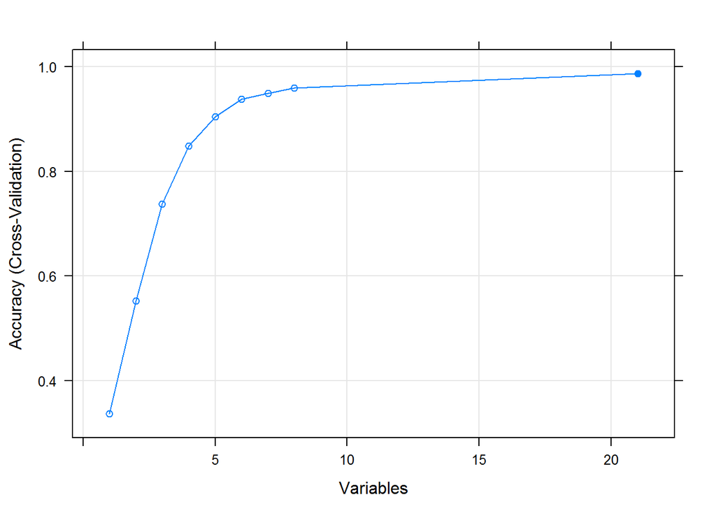

```r
# plot the results
plot(results, type=c("g", "o"))
```

4. Model was build using all 21 variables and the random forest method.

```r
#train with random forest
fitAll<-train(classe~.,data=reducedTraining, method="rf")
fitAll
```

```
## Random Forest
##
## 19622 samples
##    21 predictor
##     5 classes: 'A', 'B', 'C', 'D', 'E'
##
## No pre-processing
## Resampling: Bootstrapped (25 reps)
##
## Summary of sample sizes: 19622, 19622, 19622, 19622, 19622, 19622, ...
##
## Resampling results across tuning parameters:
##
##   mtry  Accuracy   Kappa      Accuracy SD  Kappa SD
##    2    0.9825131  0.9778693  0.001464068  0.001853245
##   11    0.9749995  0.9683645  0.002355194  0.002971975
##   21    0.9610944  0.9507688  0.003894138  0.004930560
##
## Accuracy was used to select the optimal model using  the largest value.
## The final value used for the model was mtry = 2.
```

5. Estimate of in and out of sample error rate. Prediction using part of the training data set was used to calculated the in sample error rate:

```r
# Estimate correct prediction rate
inTrain<-createDataPartition(y=training$classe, p=0.8, list= FALSE)
trainTrain<-training[inTrain, ]
trainTest<-training[-inTrain, ]
pred<-predict(fitAll, trainTest)
errorRate<-sum(trainTest$classe!=pred)/nrow(trainTest)
errorRate
```

```
## [1] 0
```

the in sample error rate is 0, because of overfiting, the out of sample error will be a little bit higher than the in sample error rate.

5. Prediction with the test data set.

```r
answers<-predict(fitAll,testing)
answers
```

```
##  [1] B A B A A E D B A A B C B A E E A B B B
## Levels: A B C D E
```